# Análisis evolución Covid-19 Chile casos y decesos (19/04/2020)

Claudio Bustos

19/4/2020

- Reportes anteriores: https://github.com/clbustos/analisis_covid19_chile

## Análisis de series de casos

La serie de casos se hace hace partir de los 25 casos, excepto para Atacama y Aysén - donde no hay casos nuevos en los últimos días, para facilitar la comparación desde un punto de un punto de partida común.

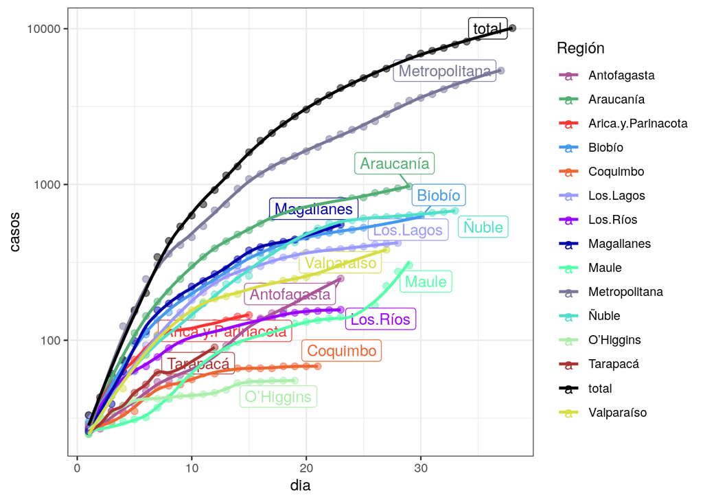

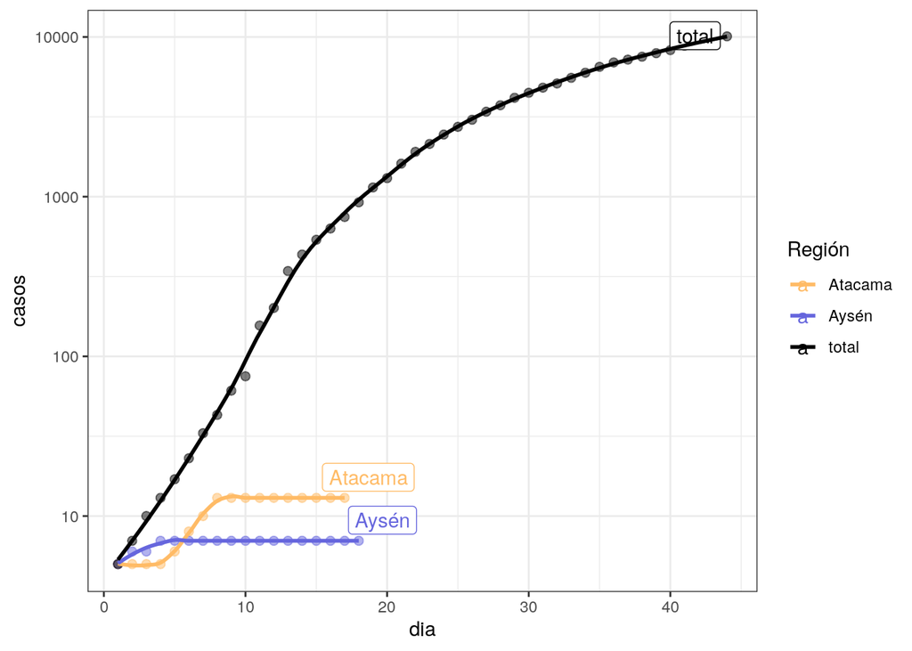

La serie por región se hace partir de los 5 primeros casos.

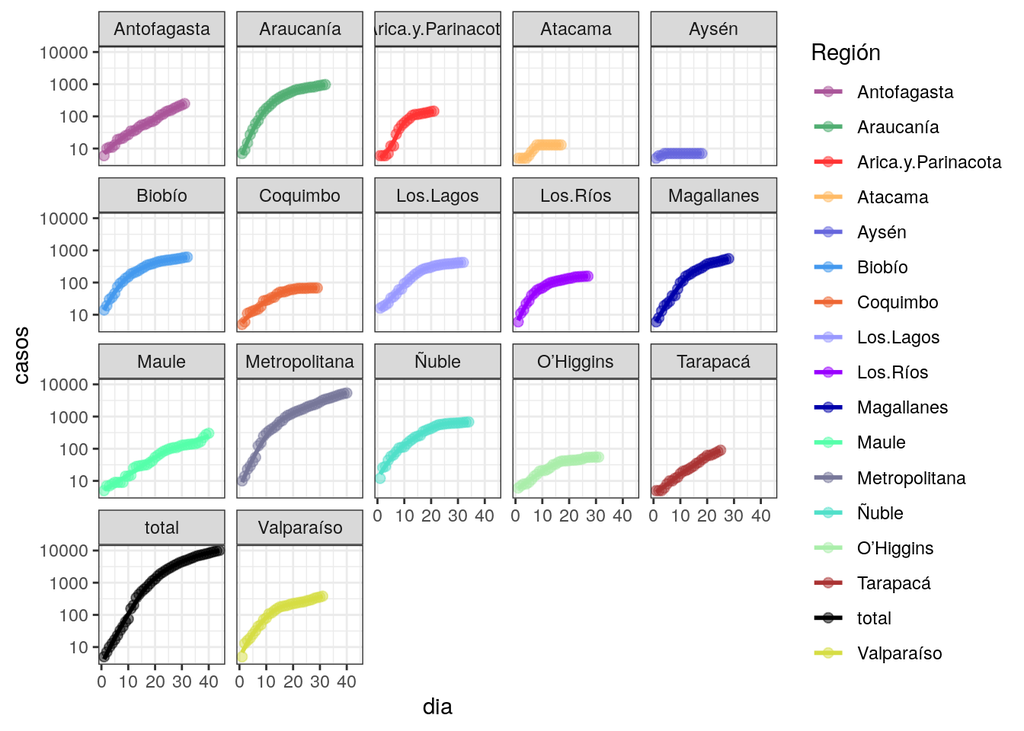

Con respecto a la cantidad de casos por día vs los del día previo, observamos aceleraciones en Arica y Parinacota, Tarapacá, Maule, Ñuble, Biobío, Araucanía y Magallanes. Se observan leves desaceleraciones en Valparaíso, Metropolitana y en la serie total.

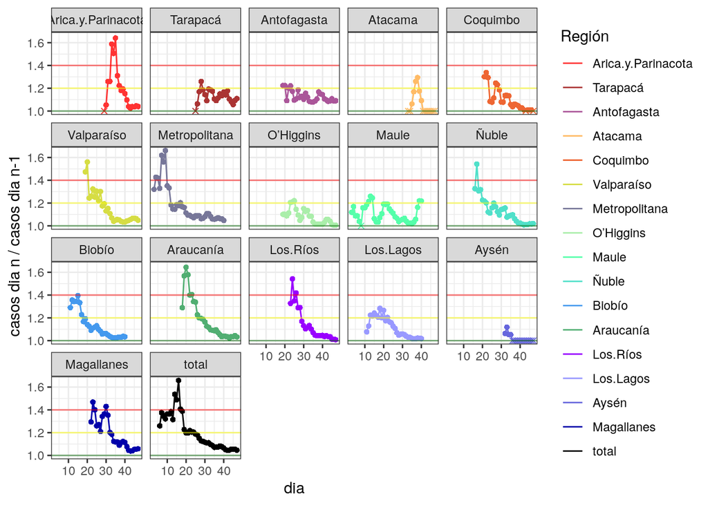

En la serie de tasas de casos nuevos, que se genera con una ventana de 5 días, se aprecia con mayor claridad la aceleración de Ñuble y la Araucanía.

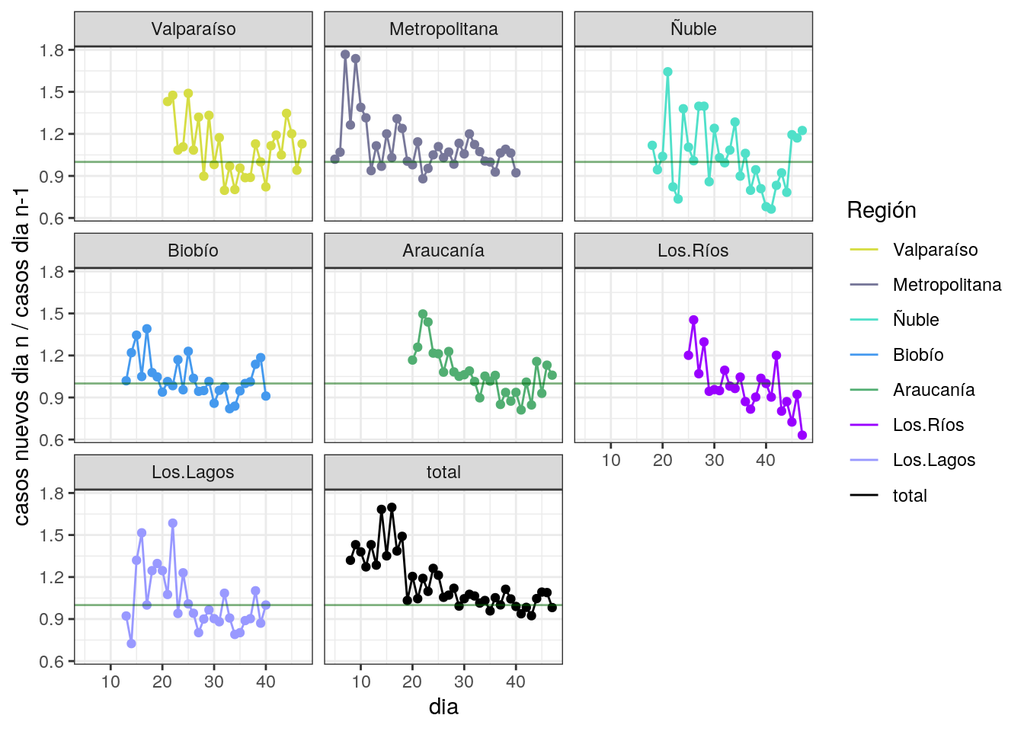

En el caso de Maule, se puede observar una pequeña desaceleración en los dos últimos días.

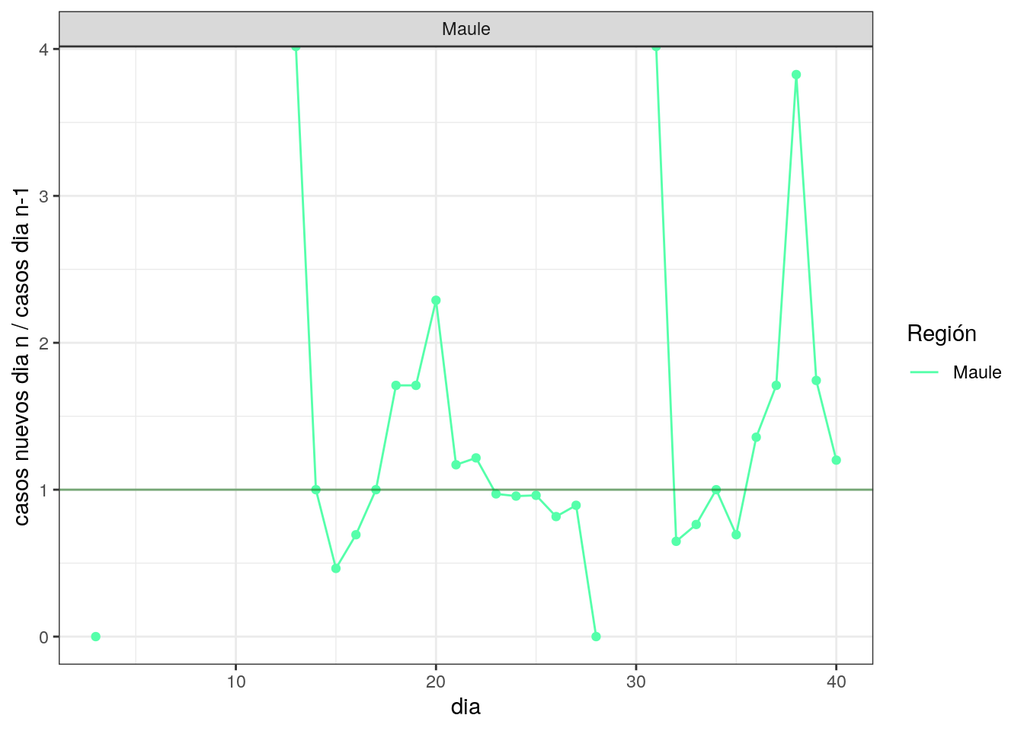

## Predicción

### Predicción para serie total

Recordemos que la regresión exponencial se eliminó, porque ya no calza con la serie total. El informe de la semana pasada mostró una subestimación constante de los modelos AR(1) + AR(4), y sobreestimación (lo que sabíamos), del modelo ARIMA. . Este último modelo se eliminará, ya que si bien los intervalos de confianza se cumplen, siempre sobreestima. A partir del análisis del resultado del algoritmo de la última semana, para la predicción total se recorta la serie a partir de lo 50 casos.

- tendencia sobre casos nuevos + AR(1) y sobre AR(4): Se modela la tendencia de los casos nuevos usando regresión exponencial, con regresión cuadradática, más la relación que existe entre mediciones contiguas. Se prueban dos modelos, uno que considera la relación solo entre cada tiempo y el anterior, AR(1), y un modelo más a largo plazo, que considera periodos de 4 días consecutivos, AR(4) . El error estándar aumenta a lo largo del tiempo, tanto por el error al calcular la tendencia, como por el componente autorregresivo. El valor medio obtenido es bastante sensible a los cambios en las mediciones finales.
- Modelo lineal cuadrático: Un modelo muy sencillo es modelar los casos totales con $ y= + _1 * dia + _2 * dia^2$, usando autocorrelación AR(2). Si bien en las pruebas muestra tener un intervalo de confianza malo y sobreestimar, tiende a tener menor error cuadrático.

|  | casos | li | ls |
| --- | --- | --- | --- |
| **Observado** | 10088 | NA | NA |
| **General: Cuadrático + AR(2)** | 10140 | 9794 | 10487 |
| **Casos nuevos : Tendencia + AR(1)** | 9292 | 8818 | 10180 |
| **Casos nuevos: Tendencia + AR(4)** | 9328 | 8872 | 10142 |

Podemos ver, al igual que en los días anteriores, que el modelo cuadrático es el más pesimista, seguido por el modelo T+AR(1), siendo el modelo AR(4) el más optimista. Considerando que los modelos AR(1) y AR(4) tienden a subestimar y el cuadrático a sobrestimar, en una semana deberíamos tener más de 12.000 casos.

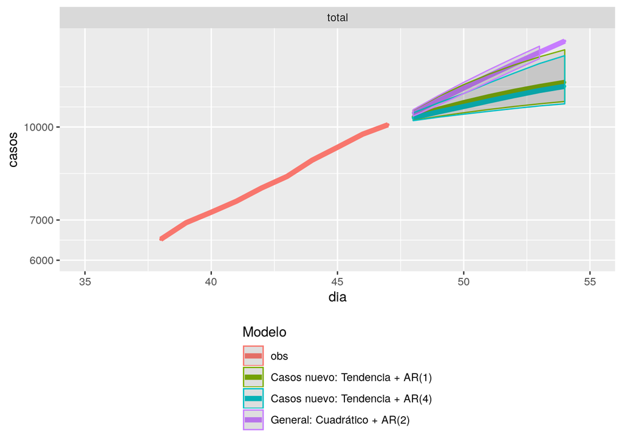

Casos nuevos: tendencia + AR(4) : total

|  | dia | casos | li | ls |
| --- | --- | --- | --- | --- |
| **37** | 48 | 10361 | 10246 | 10557 |
| **38** | 49 | 10598 | 10383 | 10970 |
| **39** | 50 | 10818 | 10504 | 11371 |
| **40** | 51 | 11052 | 10621 | 11840 |
| **41** | 52 | 11281 | 10735 | 12298 |
| **42** | 53 | 11501 | 10841 | 12755 |
| **43** | 54 | 11688 | 10930 | 13147 |

Casos nuevos: tendencia + AR(1) : total

|  | dia | casos | li | ls |
| --- | --- | --- | --- | --- |
| **37** | 48 | 10404 | 10258 | 10675 |
| **38** | 49 | 10703 | 10416 | 11241 |
| **39** | 50 | 10979 | 10562 | 11765 |
| **40** | 51 | 11234 | 10696 | 12247 |
| **41** | 52 | 11466 | 10819 | 12688 |
| **42** | 53 | 11677 | 10930 | 13087 |
| **43** | 54 | 11867 | 11030 | 13447 |

General: Modelo cuadrático : total

|  | dia | casos | li | ls |
| --- | --- | --- | --- | --- |
| **37** | 48 | 10559 | 10430 | 10688 |
| **38** | 49 | 11077 | 10874 | 11279 |
| **39** | 50 | 11618 | 11367 | 11869 |
| **40** | 51 | 12173 | 11890 | 12455 |
| **41** | 52 | 12739 | 12436 | 13042 |
| **42** | 53 | 13316 | 12998 | 13633 |
| **43** | 54 | 13902 | 13576 | 14229 |

### Predicciones para serie total usando predicción por regiones.

Otro modelo posible de análisis es usar la suma de las predicciones parciales por región. No he calculado los intervalos de confianza, porque para que sean adecuados debería considerar la covarianza entre las series de las distintas regiones.

El modelo basado en AR(1) - no se pudo calcular por hoy cuadrático - muestra un total de 13028 en una semana.

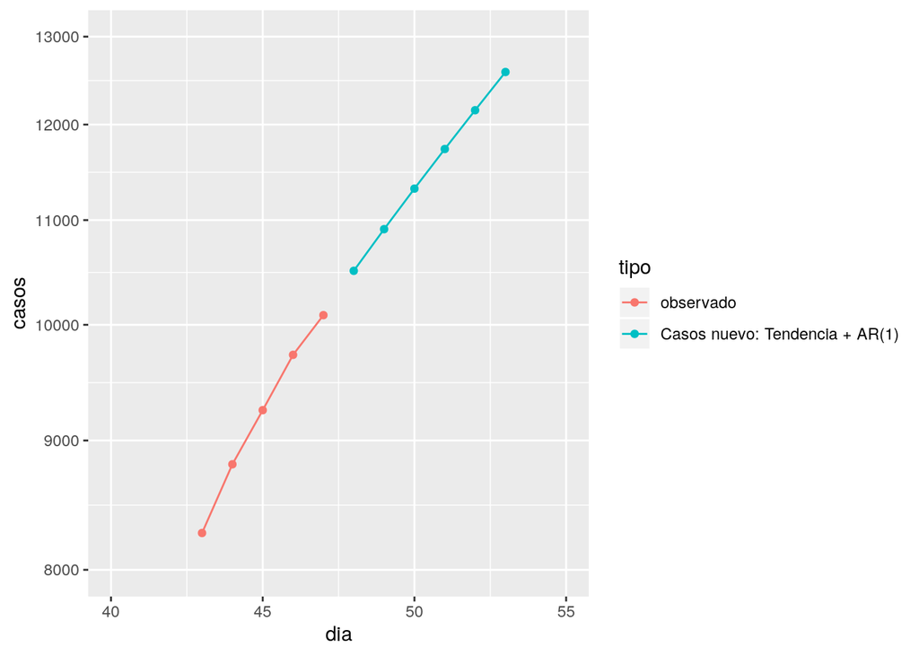

| dia | fecha | tipo | casos |
| --- | --- | --- | --- |
| 1 | 43893 | observado | 1 |
| 2 | 43894 | observado | 3 |
| 3 | 43895 | observado | 4 |
| 4 | 43896 | observado | 5 |
| 5 | 43897 | observado | 7 |
| 6 | 43898 | observado | 10 |
| 7 | 43899 | observado | 13 |
| 8 | 43900 | observado | 17 |
| 9 | 43901 | observado | 23 |
| 10 | 43902 | observado | 33 |
| 11 | 43903 | observado | 43 |
| 12 | 43904 | observado | 61 |
| 13 | 43905 | observado | 75 |
| 14 | 43906 | observado | 156 |
| 15 | 43907 | observado | 201 |
| 16 | 43908 | observado | 342 |
| 17 | 43909 | observado | 434 |
| 18 | 43910 | observado | 537 |
| 19 | 43911 | observado | 632 |
| 20 | 43912 | observado | 746 |
| 21 | 43913 | observado | 922 |
| 22 | 43914 | observado | 1142 |
| 23 | 43915 | observado | 1306 |
| 24 | 43916 | observado | 1610 |
| 25 | 43917 | observado | 1909 |
| 26 | 43918 | observado | 2139 |
| 27 | 43919 | observado | 2449 |
| 28 | 43920 | observado | 2738 |
| 29 | 43921 | observado | 3031 |
| 30 | 43922 | observado | 3404 |
| 31 | 43923 | observado | 3737 |
| 32 | 43924 | observado | 4161 |
| 33 | 43925 | observado | 4471 |
| 34 | 43926 | observado | 4815 |
| 35 | 43927 | observado | 5116 |
| 36 | 43928 | observado | 5546 |
| 37 | 43929 | observado | 5972 |
| 38 | 43930 | observado | 6501 |
| 39 | 43931 | observado | 6927 |
| 40 | 43932 | observado | 7213 |
| 41 | 43933 | observado | 7525 |
| 42 | 43934 | observado | 7917 |
| 43 | 43935 | observado | 8273 |
| 44 | 43936 | observado | 8807 |
| 45 | 43937 | observado | 9252 |
| 46 | 43938 | observado | 9730 |
| 47 | 43939 | observado | 10088 |
| 48 | 43940 | Casos nuevo: Tendencia + AR(1) | 10504 |
| 49 | 43941 | Casos nuevo: Tendencia + AR(1) | 10910 |
| 50 | 43942 | Casos nuevo: Tendencia + AR(1) | 11320 |
| 51 | 43943 | Casos nuevo: Tendencia + AR(1) | 11735 |
| 52 | 43944 | Casos nuevo: Tendencia + AR(1) | 12158 |
| 53 | 43945 | Casos nuevo: Tendencia + AR(1) | 12588 |
| 54 | 43946 | Casos nuevo: Tendencia + AR(1) | 13028 |

### Predicción por regiones

Eliminaremos la predicción de Atacama y Aysén, que presentan tasas estabilizadas. Recordemos que el algoritmo inicia desde 10 casos en cada Región.

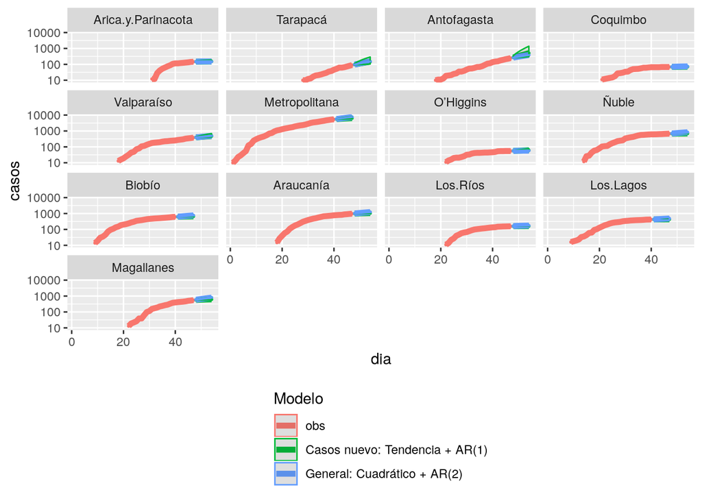

Presentamos aparte la predicción para Maule, ya que el modelo cuadrático no pudo ajustarse bien para esta región.

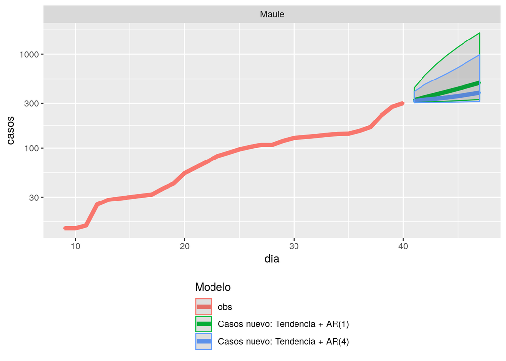

Las tablas por regiones se incluye en el Anexo I

## Ventiladores y Casos en UCI

Hoy agregamos una serie nueva, la de ventiladores en uso y pacientes en UCI. Este dato es importante, porque es el que nos indica cuando se puede producir el colapso del sistema hospitalario.

Una primera serie es la de ventiladores disponibles. Desde el día 14 al día 19, donde hay disponible datos, se ha observado un aumento de 71 casos, de 986 a 1057 ventiladores ocupados. El total también ha aumentado prácticamente en la misma proporción (77), por lo que la cantidad de ventiladores disponibles queda igual.

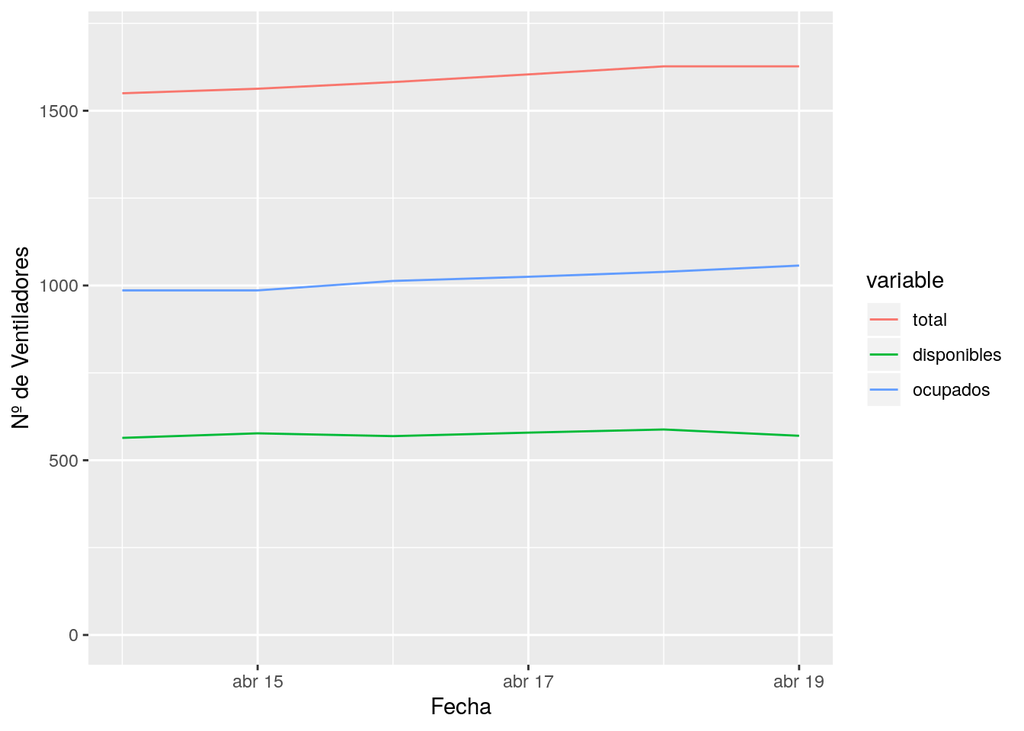

Si analizamos la serie total de pacientes en UCI para Covid-19, podemos ver que prácticamente se duplico desde inicios de mes hasta el 8 de Abril, para estabilizarse en cerca de 380 casos hasta la fecha.

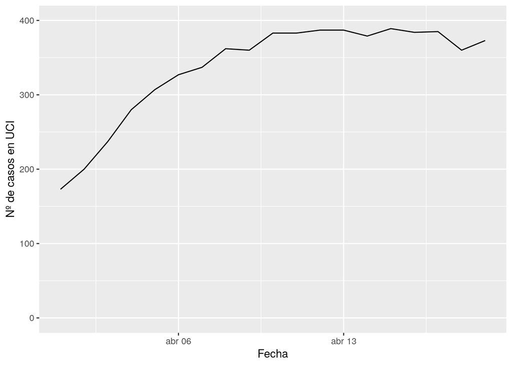

Al analizar la serie por regiones, podemos ver que en su mayoría los casos UCI se encuentran en la Región Metropolitana, siguiéndoles La Araucanía, pero con menos casos desde hace una semana.

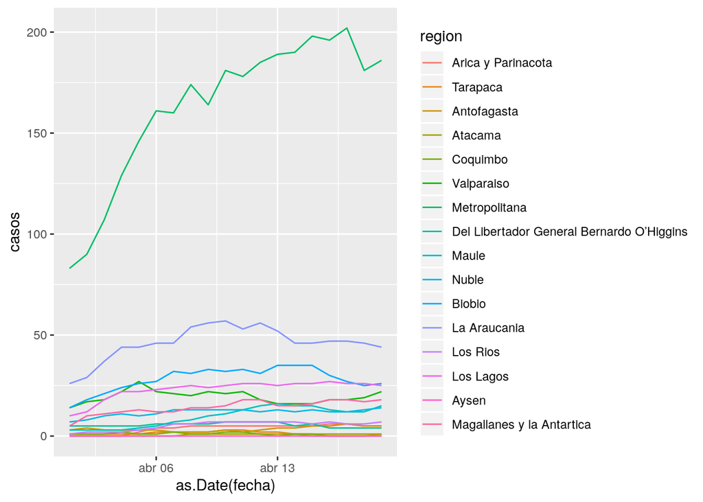

## Decesos

Si observamos la serie total de decesos, podemos observar que la desaceleración presente hace tres semanas se ha detenido, y actualmente observamos una tasa mayor, desde hace 5 días. Con ciertas variaciones, la Región Metropolitana ha mantenido la misma tasa desde hace 10 días, así como la Araucanía hace praćticamente dos semanas.

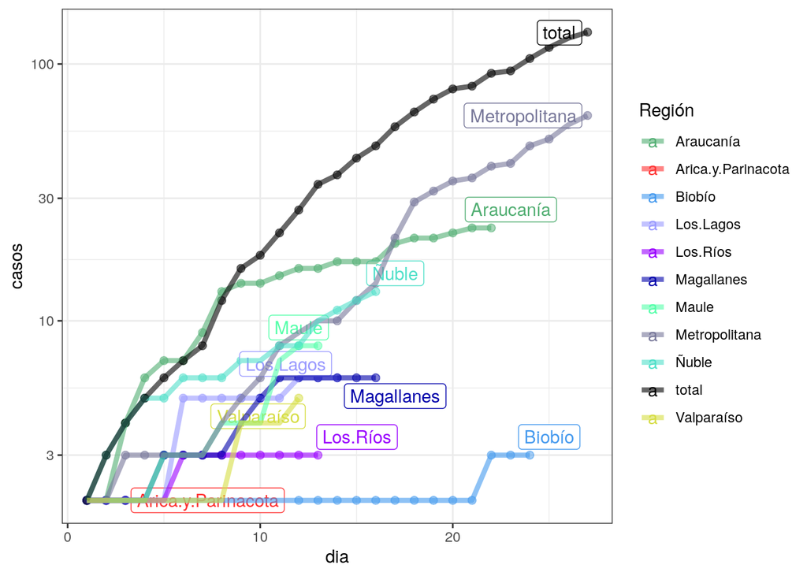

Vemos que la tasa de Ñuble ha sido relativamente constante en los últimos 10 días.

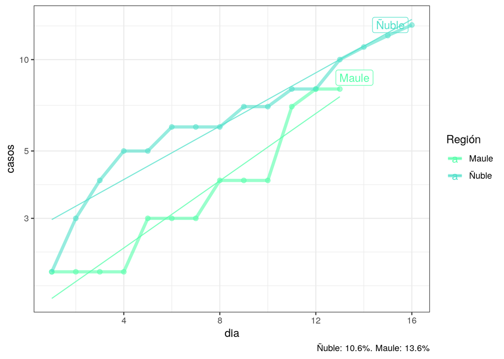

**Fuentes de información**: Principalmente, se utilizó el reporte diario del [MINSAL](https://www.minsal.cl/nuevo-coronavirus-2019-ncov/casos-confirmados-en-chile-covid-19/), usando [Wayback machine](https://archive.org/web/) para recopilar la información ya no disponible. También se ocupa la nueva serie disponible en el [Github del Ministerio de Ciencias](https://github.com/MinCiencia/Datos-COVID19).

## Anexo I: Predicciones por región

Casos nuevos: tendencia + AR(1) : Arica.y.Parinacota

|  | dia | casos | li | ls |
| --- | --- | --- | --- | --- |
| **18** | 48 | 147.1 | 145.3 | 158 |
| **19** | 49 | 148.7 | 145.6 | 167.6 |
| **20** | 50 | 149.8 | 145.8 | 174.5 |
| **21** | 51 | 150.5 | 145.9 | 179.2 |
| **22** | 52 | 151.1 | 146 | 182.4 |
| **23** | 53 | 151.4 | 146 | 184.5 |
| **24** | 54 | 151.6 | 146.1 | 185.8 |

Casos nuevos: tendencia + AR(1) : Tarapacá

|  | dia | casos | li | ls |
| --- | --- | --- | --- | --- |
| **21** | 48 | 96.86 | 91.95 | 114.1 |
| **22** | 49 | 104.4 | 94.06 | 140.9 |
| **23** | 50 | 112.2 | 96.25 | 168.7 |
| **24** | 51 | 120.2 | 98.51 | 197.5 |
| **25** | 52 | 128.6 | 100.9 | 227.2 |
| **26** | 53 | 137.2 | 103.3 | 257.8 |
| **27** | 54 | 146 | 105.7 | 289.1 |

Casos nuevos: tendencia + AR(1) : Antofagasta

|  | dia | casos | li | ls |
| --- | --- | --- | --- | --- |
| **31** | 48 | 273.7 | 254.8 | 354.6 |
| **32** | 49 | 301.7 | 261.1 | 479.1 |
| **33** | 50 | 333.1 | 268.1 | 619.1 |
| **34** | 51 | 368.5 | 276.1 | 776.7 |
| **35** | 52 | 408.3 | 285 | 954.1 |
| **36** | 53 | 453.2 | 295.1 | 1154 |
| **37** | 54 | 503.8 | 306.4 | 1380 |

Casos nuevos: tendencia + AR(1) : Coquimbo

|  | dia | casos | li | ls |
| --- | --- | --- | --- | --- |
| **28** | 48 | 68.58 | 68.14 | 70.32 |
| **29** | 49 | 69.07 | 68.26 | 72.31 |
| **30** | 50 | 69.46 | 68.36 | 73.9 |
| **31** | 51 | 69.77 | 68.44 | 75.16 |
| **32** | 52 | 70.01 | 68.5 | 76.14 |
| **33** | 53 | 70.19 | 68.54 | 76.89 |
| **34** | 54 | 70.33 | 68.58 | 77.46 |

Casos nuevos: tendencia + AR(1) : Valparaíso

|  | dia | casos | li | ls |
| --- | --- | --- | --- | --- |
| **31** | 48 | 395.9 | 385.7 | 428.2 |
| **32** | 49 | 409.8 | 390 | 473.1 |
| **33** | 50 | 423.4 | 394.2 | 516.9 |
| **34** | 51 | 436.8 | 398.4 | 560 |
| **35** | 52 | 449.9 | 402.5 | 602.2 |
| **36** | 53 | 462.8 | 406.5 | 643.4 |
| **37** | 54 | 475.2 | 410.4 | 683.5 |

Casos nuevos: tendencia + AR(1) : Metropolitana

|  | dia | casos | li | ls |
| --- | --- | --- | --- | --- |
| **41** | 41 | 5564 | 5457 | 5821 |
| **42** | 42 | 5737 | 5528 | 6247 |
| **43** | 43 | 5899 | 5593 | 6646 |
| **44** | 44 | 6048 | 5654 | 7015 |
| **45** | 45 | 6186 | 5709 | 7354 |
| **46** | 46 | 6311 | 5760 | 7662 |
| **47** | 47 | 6424 | 5806 | 7942 |

Casos nuevos: tendencia + AR(1) : O’Higgins

|  | dia | casos | li | ls |
| --- | --- | --- | --- | --- |
| **27** | 48 | 56.02 | 55.3 | 58.45 |
| **28** | 49 | 57.02 | 55.6 | 61.82 |
| **29** | 50 | 57.98 | 55.88 | 65.09 |
| **30** | 51 | 58.92 | 56.16 | 68.26 |
| **31** | 52 | 59.83 | 56.42 | 71.35 |
| **32** | 53 | 60.71 | 56.69 | 74.34 |
| **33** | 54 | 61.57 | 56.94 | 77.25 |

Casos nuevos: tendencia + AR(1) : Ñuble

|  | dia | casos | li | ls |
| --- | --- | --- | --- | --- |
| **35** | 48 | 683.2 | 679.2 | 700.8 |
| **36** | 49 | 687.3 | 680.1 | 719 |
| **37** | 50 | 690.7 | 680.9 | 733.8 |
| **38** | 51 | 693.4 | 681.5 | 745.8 |
| **39** | 52 | 695.6 | 682 | 755.5 |
| **40** | 53 | 697.3 | 682.4 | 763 |
| **41** | 54 | 698.6 | 682.7 | 769 |

Casos nuevos: tendencia + AR(1) : Biobío

|  | dia | casos | li | ls |
| --- | --- | --- | --- | --- |
| **33** | 41 | 625.5 | 620.2 | 637.7 |
| **34** | 42 | 634 | 623.9 | 657.2 |
| **35** | 43 | 641.5 | 627.1 | 674.3 |
| **36** | 44 | 647.9 | 629.9 | 689.1 |
| **37** | 45 | 653.4 | 632.3 | 701.7 |
| **38** | 46 | 658 | 634.3 | 712.5 |
| **39** | 47 | 662 | 636 | 721.5 |

Casos nuevos: tendencia + AR(1) : Araucanía

|  | dia | casos | li | ls |
| --- | --- | --- | --- | --- |
| **31** | 48 | 990.2 | 980 | 1013 |
| **32** | 49 | 1006 | 986.8 | 1049 |
| **33** | 50 | 1019 | 992.7 | 1080 |
| **34** | 51 | 1031 | 997.9 | 1107 |
| **35** | 52 | 1041 | 1002 | 1130 |
| **36** | 53 | 1050 | 1006 | 1150 |
| **37** | 54 | 1057 | 1009 | 1167 |

Casos nuevos: tendencia + AR(1) : Los.Ríos

|  | dia | casos | li | ls |
| --- | --- | --- | --- | --- |
| **27** | 48 | 158.1 | 157.4 | 159.5 |
| **28** | 49 | 158.8 | 157.8 | 161.4 |
| **29** | 50 | 159.4 | 158 | 162.9 |
| **30** | 51 | 159.9 | 158.2 | 164 |
| **31** | 52 | 160.2 | 158.3 | 164.8 |
| **32** | 53 | 160.5 | 158.4 | 165.5 |
| **33** | 54 | 160.7 | 158.5 | 165.9 |

Casos nuevos: tendencia + AR(1) : Los.Lagos

|  | dia | casos | li | ls |
| --- | --- | --- | --- | --- |
| **33** | 41 | 423.4 | 421.8 | 427.8 |
| **34** | 42 | 425.3 | 422.5 | 433.4 |
| **35** | 43 | 426.8 | 423 | 437.6 |
| **36** | 44 | 427.8 | 423.4 | 440.6 |
| **37** | 45 | 428.5 | 423.6 | 442.8 |
| **38** | 46 | 429.1 | 423.8 | 444.4 |
| **39** | 47 | 429.4 | 423.9 | 445.4 |

Casos nuevos: tendencia + AR(1) : Magallanes

|  | dia | casos | li | ls |
| --- | --- | --- | --- | --- |
| **27** | 48 | 567 | 556.6 | 607.8 |
| **28** | 49 | 580.7 | 560 | 662.7 |
| **29** | 50 | 592.1 | 562.8 | 708.4 |
| **30** | 51 | 601.6 | 565.2 | 746.7 |
| **31** | 52 | 609.5 | 567.2 | 778.2 |
| **32** | 53 | 615.8 | 568.7 | 803.8 |
| **33** | 54 | 620.9 | 570 | 824.1 |

General: cuadrático + AR(2) : Arica.y.Parinacota

|  | dia | casos | li | ls |
| --- | --- | --- | --- | --- |
| **18** | 48 | 147.5 | 138 | 157 |
| **19** | 49 | 149.8 | 138.2 | 161.3 |
| **20** | 50 | 151.4 | 139.8 | 163 |
| **21** | 51 | 152.4 | 140.7 | 164.1 |
| **22** | 52 | 152.6 | 140.8 | 164.5 |
| **23** | 53 | 152.1 | 140.3 | 164 |
| **24** | 54 | 151 | 139.1 | 162.8 |

General: cuadrático + AR(2) : Tarapacá

|  | dia | casos | li | ls |
| --- | --- | --- | --- | --- |
| **21** | 48 | 97.74 | 93.87 | 101.6 |
| **22** | 49 | 105.5 | 101.3 | 109.7 |
| **23** | 50 | 113.9 | 109.7 | 118.1 |
| **24** | 51 | 122.8 | 118.6 | 127 |
| **25** | 52 | 132.1 | 127.9 | 136.3 |
| **26** | 53 | 141.7 | 137.5 | 146 |
| **27** | 54 | 151.7 | 147.5 | 155.9 |

General: cuadrático + AR(2) : Antofagasta

|  | dia | casos | li | ls |
| --- | --- | --- | --- | --- |
| **31** | 48 | 265.5 | 257.1 | 274 |
| **32** | 49 | 283.5 | 273.2 | 293.8 |
| **33** | 50 | 302.3 | 291.1 | 313.5 |
| **34** | 51 | 321.9 | 310.3 | 333.6 |
| **35** | 52 | 342.4 | 330.4 | 354.3 |
| **36** | 53 | 363.6 | 351.4 | 375.7 |
| **37** | 54 | 385.5 | 373.2 | 397.7 |

General: cuadrático + AR(2) : Coquimbo

|  | dia | casos | li | ls |
| --- | --- | --- | --- | --- |
| **28** | 48 | 69.36 | 64.47 | 74.25 |
| **29** | 49 | 70.78 | 64.06 | 77.5 |
| **30** | 50 | 71.95 | 64.45 | 79.44 |
| **31** | 51 | 72.82 | 65.01 | 80.63 |
| **32** | 52 | 73.45 | 65.52 | 81.38 |
| **33** | 53 | 73.88 | 65.9 | 81.85 |
| **34** | 54 | 74.13 | 66.14 | 82.12 |

General: cuadrático + AR(2) : Valparaíso

|  | dia | casos | li | ls |
| --- | --- | --- | --- | --- |
| **31** | 48 | 397.2 | 383.1 | 411.3 |
| **32** | 49 | 413.2 | 394.1 | 432.2 |
| **33** | 50 | 429.4 | 407.8 | 451 |
| **34** | 51 | 445.9 | 422.8 | 469 |
| **35** | 52 | 462.7 | 438.8 | 486.7 |
| **36** | 53 | 479.9 | 455.4 | 504.4 |
| **37** | 54 | 497.3 | 472.5 | 522.1 |

General: cuadrático + AR(2) : Metropolitana

|  | dia | casos | li | ls |
| --- | --- | --- | --- | --- |
| **41** | 41 | 5640 | 5551 | 5728 |
| **42** | 42 | 5936 | 5813 | 6059 |
| **43** | 43 | 6249 | 6115 | 6383 |
| **44** | 44 | 6568 | 6432 | 6704 |
| **45** | 45 | 6890 | 6754 | 7026 |
| **46** | 46 | 7216 | 7080 | 7352 |
| **47** | 47 | 7547 | 7411 | 7684 |

General: cuadrático + AR(2) : O’Higgins

|  | dia | casos | li | ls |
| --- | --- | --- | --- | --- |
| **27** | 48 | 55.64 | 52.74 | 58.53 |
| **28** | 49 | 56.39 | 52.6 | 60.19 |
| **29** | 50 | 57.01 | 53.03 | 60.98 |
| **30** | 51 | 57.43 | 53.45 | 61.41 |
| **31** | 52 | 57.68 | 53.7 | 61.66 |
| **32** | 53 | 57.81 | 53.82 | 61.8 |
| **33** | 54 | 57.84 | 53.85 | 61.83 |

General: cuadrático + AR(2) : Ñuble

|  | dia | casos | li | ls |
| --- | --- | --- | --- | --- |
| **35** | 48 | 696.8 | 665.5 | 728.1 |
| **36** | 49 | 718.6 | 667.9 | 769.3 |
| **37** | 50 | 741.3 | 677.1 | 805.6 |
| **38** | 51 | 764.1 | 690.6 | 837.7 |
| **39** | 52 | 786.7 | 706.8 | 866.7 |
| **40** | 53 | 809 | 724.6 | 893.4 |
| **41** | 54 | 830.9 | 743.5 | 918.4 |

General: cuadrático + AR(2) : Biobío

|  | dia | casos | li | ls |
| --- | --- | --- | --- | --- |
| **33** | 41 | 633.8 | 616.3 | 651.3 |
| **34** | 42 | 654.5 | 627 | 681.9 |
| **35** | 43 | 676 | 642 | 710 |
| **36** | 44 | 697.7 | 659.5 | 735.9 |
| **37** | 45 | 719.3 | 678.4 | 760.2 |
| **38** | 46 | 740.8 | 698.1 | 783.5 |
| **39** | 47 | 762.1 | 718.3 | 806 |

General: cuadrático + AR(2) : Araucanía

|  | dia | casos | li | ls |
| --- | --- | --- | --- | --- |
| **31** | 48 | 1006 | 980 | 1033 |
| **32** | 49 | 1043 | 1001 | 1086 |
| **33** | 50 | 1081 | 1028 | 1135 |
| **34** | 51 | 1120 | 1060 | 1180 |
| **35** | 52 | 1158 | 1093 | 1222 |
| **36** | 53 | 1196 | 1129 | 1263 |
| **37** | 54 | 1233 | 1165 | 1302 |

General: cuadrático + AR(2) : Los.Ríos

|  | dia | casos | li | ls |
| --- | --- | --- | --- | --- |
| **27** | 48 | 161.3 | 155.9 | 166.7 |
| **28** | 49 | 165 | 158.7 | 171.3 |
| **29** | 50 | 167.6 | 161.2 | 174 |
| **30** | 51 | 169.5 | 163.1 | 175.9 |
| **31** | 52 | 171 | 164.6 | 177.4 |
| **32** | 53 | 172.2 | 165.8 | 178.6 |
| **33** | 54 | 173.2 | 166.8 | 179.6 |

General: cuadrático + AR(2) : Los.Lagos

|  | dia | casos | li | ls |
| --- | --- | --- | --- | --- |
| **33** | 41 | 428.1 | 411.5 | 444.8 |
| **34** | 42 | 436.6 | 405.1 | 468.1 |
| **35** | 43 | 445.8 | 400.2 | 491.4 |
| **36** | 44 | 455.4 | 396.9 | 513.9 |
| **37** | 45 | 465.3 | 395 | 535.5 |
| **38** | 46 | 475.2 | 394.3 | 556.2 |
| **39** | 47 | 485.3 | 394.5 | 576.1 |

General: cuadrático + AR(2) : Magallanes

|  | dia | casos | li | ls |
| --- | --- | --- | --- | --- |
| **27** | 48 | 587.7 | 565.8 | 609.6 |
| **28** | 49 | 623.1 | 591.6 | 654.5 |
| **29** | 50 | 658.3 | 622.6 | 694 |
| **30** | 51 | 693.3 | 656 | 730.5 |
| **31** | 52 | 728.3 | 690.5 | 766 |
| **32** | 53 | 763.5 | 725.6 | 801.4 |
| **33** | 54 | 799.1 | 761.2 | 837.1 |